# Time Series Analysis

#### Homework5 201811526 이은주

### 3. SavingsRate

#### [STEP 1] 시계열 데이터 처리

```r
saving = read.table("SavingsRate.txt") %>%
  pivot_longer(V1:V4, names_to="branch", values_to="rate")
saving_ts = ts(saving$rate, start=c(1955,1), frequency=4)
head(saving_ts); tail(saving_ts)
```

```
##      Qtr1 Qtr2 Qtr3 Qtr4
## 1955  4.9  5.2  5.7  5.7
## 1956  6.2  6.7
```

```
##      Qtr1 Qtr2 Qtr3 Qtr4
## 1979            4.8  4.7
## 1980  5.0  5.4  4.3  3.5
```

(행, 열)로 이루어진 SavingRate의 데이터를 하나의 행으로 변환하여 시계열 데이터로 변환하기 쉽도록 하였습니다. 변환 결과, 1955년부터 1980년까지 4분기 데이터를 볼 수 있습니다.

#### [STEP 2] 시계열 그래프

SavingRate 데이터의 시계열 그래프를 통해 시간 흐름에 따른 특징을 알아봅니다.

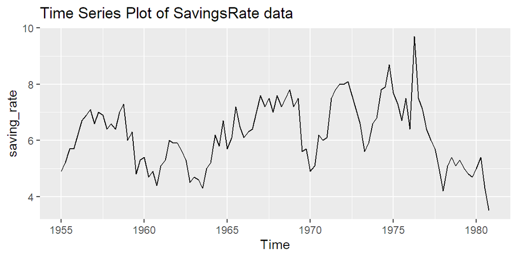

```r
autoplot(saving_ts) + ylab("saving_rate") +
  ggtitle("Time Series Plot of SavingsRate data")
```

전반적으로 6%에서 크게 벗어나지는 않지만, 중간 중간 예측 불가능한 큰 하락과 상승이 있는 것으로 보입니다.  
특히 1970년 후반에 급격히 큰 하락이 있었습니다.

#### [STEP 3] ACF, PACF

ACF(자기상관함수) : t시간의 차이가 있는 두 관측값의 상관성  
PACF(부분자기상관함수) : 상관성을 비교하기 위한 두 관측값 외 다른 관측값을 제외 후, 두 관측값의 상관성

AR(p) : ACF가 지수적으로 또는 sin함수 형태로 감소하며, PACF가 p+1차 이후 절단되어 보입니다.  
MA(q) : ACF가 q+1차 이후 절단되며, PACF가 지수적으로 또는 sin함수 형태로 감소합니다.  
ARMA(p,q) : ACF는 q-p+1차부터, PACF는 p-q+1차부터 지수적으로 또는 sin함수 형태로 감소합니다.

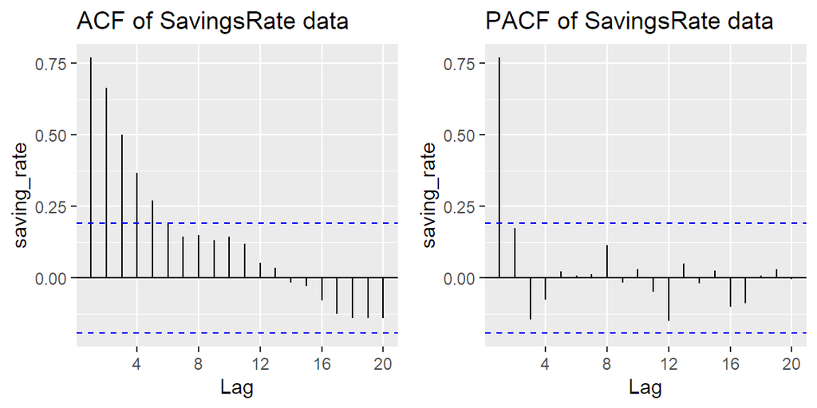

```r
p1 = ggAcf(saving_ts) + ylab("saving_rate") + ggtitle("ACF of SavingsRate data")
p2 = ggPacf(saving_ts) + ylab("saving_rate") + ggtitle("PACF of SavingsRate data")
grid.arrange(p1, p2, ncol=2)
```

ACF가 sin 함수 형태로 천천히 감소하고 PACF가 시차2 이후부터 절단된 것으로 보이므로 AR(1) 모델을 임의로 선택합니다.  
또한 ARMA모형일 가능성을 고려하여 ARMA(1,1) 모델 또한 고려하고 PACF의 시차2에 대한 값이 유의수준 경계에 매우 가까우므로 AR(2) model 또한 고려해봅니다.

#### [STEP 4] Best model 선택

train data : 모델 선택을 위한 학습용 데이터  
test data : 최종 선택한 모델의 최종 성능 평가를 위한 데이터

```r
train_saving = saving_ts[1:80]
test_saving = saving_ts[81:104]
```

##### (1) 모델 적합

- AR(1) model

```r
arimaModel_100 = arima(train_saving, order=c(1,0,0)) ;print(arimaModel_100)
```

```
##
## Call:
## arima(x = train_saving, order = c(1, 0, 0))
##
## Coefficients:
##          ar1  intercept
##       0.8516     6.3788
## s.e.  0.0630     0.4131
##
## sigma^2 estimated as 0.3423:  log likelihood = -71.28,  aic = 148.55
```

AR(1) model : $Y_t$ = 6.3788 + 0.8516$Y_{t-1}$ + $a_t$, $a_t$:WN  
* ARMA(1,1) model

```r
arimaModel_101 = arima(train_saving, order=c(1,0,1)) ; print(arimaModel_101)
```

```
##
## Call:
## arima(x = train_saving, order = c(1, 0, 1))
##
## Coefficients:
##          ar1      ma1  intercept
##       0.8672  -0.0504     6.3841
## s.e.  0.0669   0.1019     0.4344
##
## sigma^2 estimated as 0.3412:  log likelihood = -71.16,  aic = 150.31
```

ARMA(1,1) model : $Y_t$ = 6.3841 + 0.8671$Y_{t-1}$ + $a_t$ + 0.0504$a_{t-1}$, $a_t$:WN

* AR(2) model

```r
arimaModel_200 = arima(train_saving, order=c(2,0,0)) ; print(arimaModel_200)
```

```
##
## Call:
## arima(x = train_saving, order = c(2, 0, 0))
##
## Coefficients:
##          ar1     ar2  intercept
##       0.7909  0.0745     6.3873
## s.e.  0.1128  0.1151     0.4483
##
## sigma^2 estimated as 0.3404:  log likelihood = -71.07,  aic = 150.14
```

AR(2) model : $Y_t$ = 6.3873 + 0.7909$Y_{t-1}$ + 0.0745$Y_{t-2} + $a_t$, $a_t$:WN

```r
AutoarimaModel = auto.arima(train_saving) ; print(AutoarimaModel)
```

```
## Series: train_saving
## ARIMA(0,1,0)
##
## sigma^2 estimated as 0.3646:  log likelihood=-72.24
## AIC=146.48   AICc=146.53   BIC=148.85
```

ARIMA(0,1,0) model : $\Delta Y_t$ = $\mu$ + $\Delta Y_{t-1}$  
-> 비정상성 모델(Random Walk)로 정상성을 만족하지 않는 시계열에 대한 모델입니다.

세 개의 모델의 AIC를 보면, AR(1):148.55, AR(2)150.14, ARMA(1,1):150.31, ARIMA(0,1,0):146.48으로 Auto ARIMA 모델의 AIC값이 가장 작습니다.  
하지만 각 모델의 특징을 알아보고 나서 최종 모델을 선택하도록 하겠습니다.

##### (2) 정상성 : 시간이 흐름에도 확률적 성질이 변하지 않는 성질

모델의 특성방정식 근 절대값이 1보다 클 때, 정상성을 만족합니다.  
즉 역근의 절대값이 1보다 작아야 하므로 원 안에 역근이 있으면 정상성을 만족한다고 할 수 있습니다.

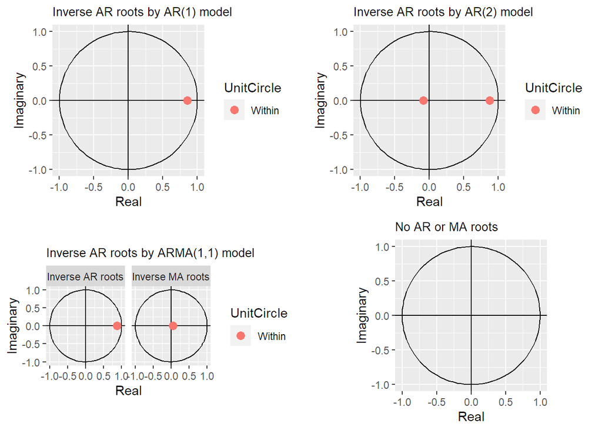

```r
p1=autoplot(arimaModel_100) + ggtitle("Inverse AR roots by AR(1) model") +
  theme(plot.title = element_text(size=10))
p2=autoplot(arimaModel_200) + ggtitle("Inverse AR roots by AR(2) model") +
  theme(plot.title = element_text(size=10))
p3=autoplot(arimaModel_101) + ggtitle("Inverse AR roots by ARMA(1,1) model") +
  theme(plot.title = element_text(size=10))
p4=autoplot(AutoarimaModel) +
  theme(plot.title = element_text(size=10))
grid.arrange(p1,p2,p3,p4, ncol=2)
```

AR(1), AR(2), AR(1,1) 모델은 정상성을 만족하는 것으로 보이며 Autoarima모델은 비정상성 모델이므로 원 안에 역근이 존재하지 않습니다.

##### (3) 잔차의 독립성 및 정규성

잔차의 분포를 통해 정규성을 확인하고, ACF값이 유의수준 내에 있다면 잔차의 자기상관성이 없다고 할 수 있습니다.  
잔차의 독립성에 대해 정확히 알아보기 위해 Ljung-Box test 검정(H0:잔차가 독립) 또한 진행합니다.

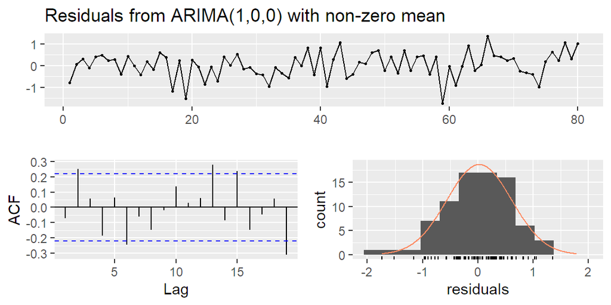

```
##
##  Ljung-Box test
##
## data:  Residuals from ARIMA(1,0,0) with non-zero mean
## Q* = 18.844, df = 8, p-value = 0.01572
##
## Model df: 2.   Total lags used: 10
```

```r
checkresiduals(arimaModel_100)
```

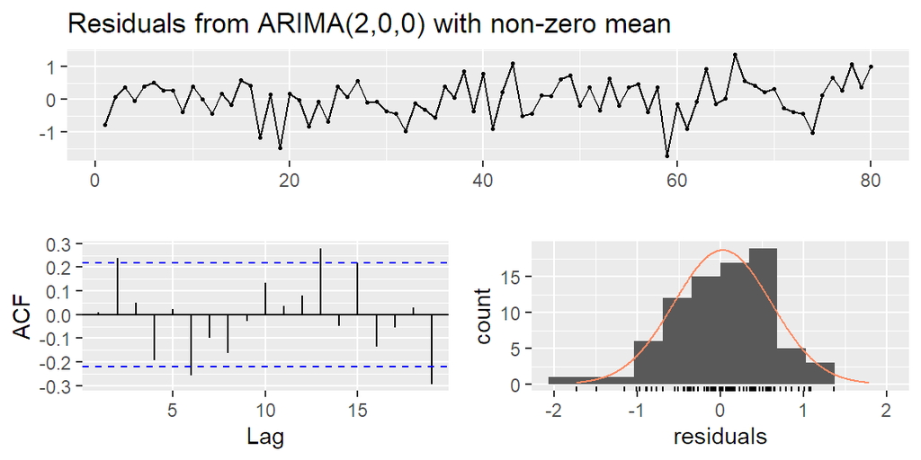

```
##
##  Ljung-Box test
##
## data:  Residuals from ARIMA(2,0,0) with non-zero mean
## Q* = 19.206, df = 7, p-value = 0.007565
##
## Model df: 3.   Total lags used: 10
```

```r
checkresiduals(arimaModel_200)
```

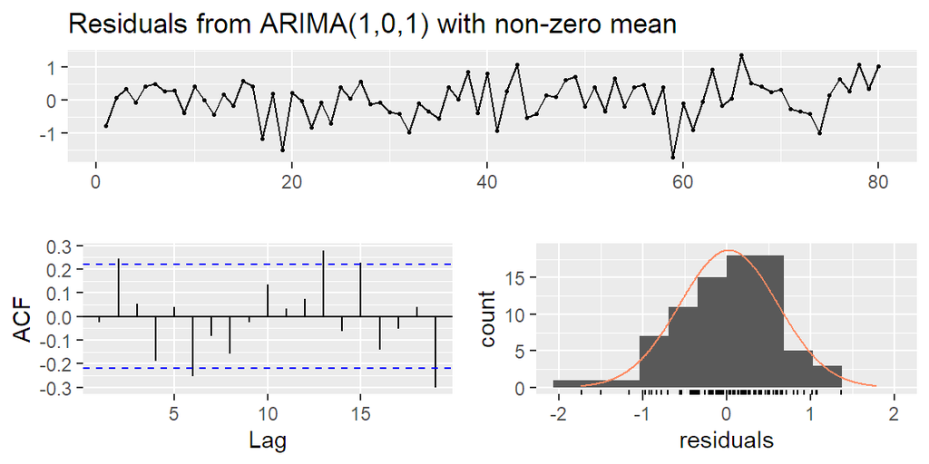

```
##
##  Ljung-Box test
##
## data:  Residuals from ARIMA(1,0,1) with non-zero mean
## Q* = 18.945, df = 7, p-value = 0.008363
##
## Model df: 3.   Total lags used: 10
```

```r
checkresiduals(arimaModel_101)
```

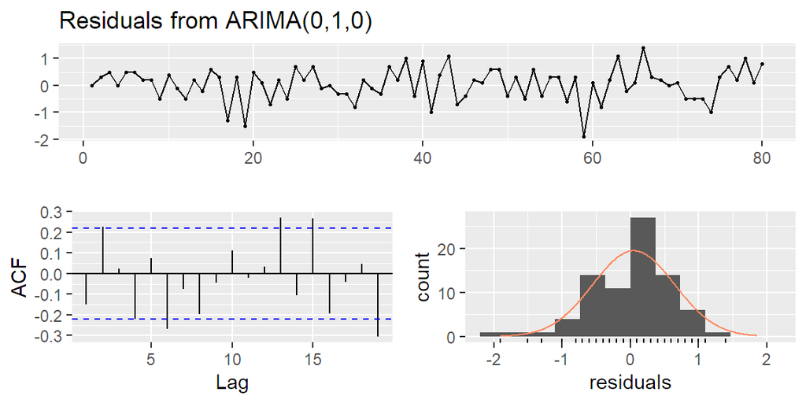

```
##
##  Ljung-Box test
##
## data:  Residuals from ARIMA(0,1,0)
## Q* = 22.695, df = 10, p-value = 0.01193
##
## Model df: 0.   Total lags used: 10
```

```r
checkresiduals(AutoarimaModel)
```

네개의 모델 모두 정규성은 따르나 검정 결과 잔차들이 독립이라고 할 수 없습니다.  
잔차가 독립이 아니라는 의미는 잔차에 모델이 설명하지 못한 부분이 있는 것입니다.  
이는 잔차로 식이 이루어지는 MA모델의 차수를 높일 필요가 있습니다. 이에 따라 기존 고려했던 모델에서 MA차수를 2로 두어 ARMA(1,2), ARMA(2,2)에 대해 고려해보록 하겠습니다.

##### 다시 (1)모델 적합부터 시작

- ARIMA(1,0,2) model

```r
arimaModel_102 = arima(train_saving, order=c(1,0,2)) ;print(arimaModel_102)
```

```
##
## Call:
## arima(x = train_saving, order = c(1, 0, 2))
##
## Coefficients:
##          ar1     ma1     ma2  intercept
##       0.7568  0.0217  0.4442     6.3569
## s.e.  0.1045  0.1229  0.1454     0.3532
##
## sigma^2 estimated as 0.2997:  log likelihood = -66.2,  aic = 142.4
```

ARIMA(1,0,2) model = $Y_t$ = 6.3569 + 0.7568$Y_{t-1}$ + $a_t$ - 0.0217$a_{t-1}$ - 0.4442$a_{t-2}$, $a_t$:WN

- ARIMA(2,0,2) model

```r
arimaModel_202 = arima(train_saving, order=c(2,0,2)) ; print(arimaModel_202)
```

```
##
## Call:
## arima(x = train_saving, order = c(2, 0, 2))
##
## Coefficients:
##          ar1      ar2      ma1     ma2  intercept
##       0.7882  -0.0307  -0.0034  0.4424     6.3564
## s.e.  0.2509   0.2166   0.2245  0.1476     0.3483
##
## sigma^2 estimated as 0.2997:  log likelihood = -66.19,  aic = 144.38
```

ARIMA(2,0,2) model = $Y_t$ = 6.3564 + 0.7882$Y_{t-1}$ - 0.0307$Y_{t-1}$ + $a_t$ + 0.0034$a_{t-1}$ - 0.4424$a_{t-2}$, $a_t$:WN

AIC값이 ARIMA(1,0,2):142.4, ARIMA(2,0,2):144.38으로 앞서 보왔던 모든 모델 중에서 ARIMA(1,0,2)모델이 가장 작은 AIC값을 가지고 있는 것을 알 수 있습니다. ARIMA(2,0,2) 또한 그 다음으로 가장 작습니다.

두 모델이 정상성을 만족하고 잔차가 정규성을 지니고 독립인지 확인해보도록 하겠습니다.

(2) 정상성 만족

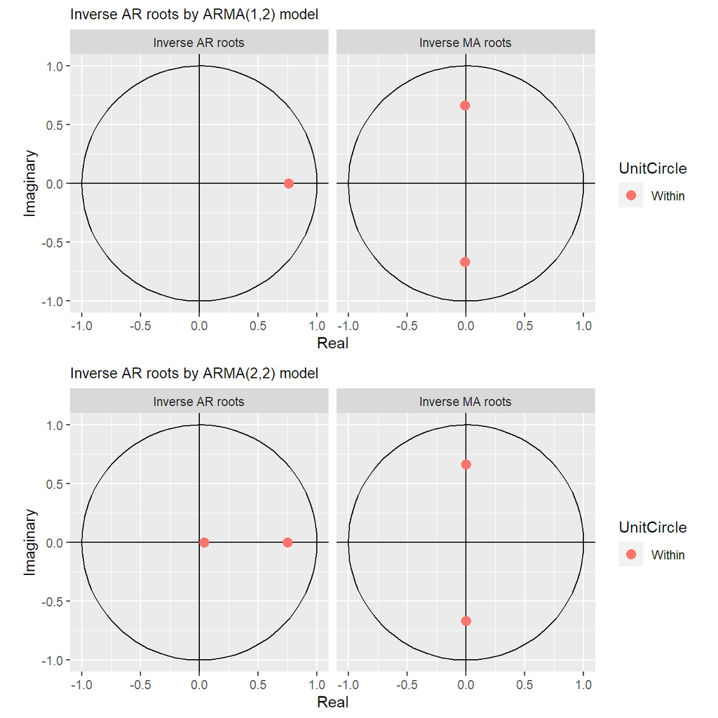

```r
p1 =autoplot(arimaModel_102) + ggtitle("Inverse AR roots by ARMA(1,2) model") +
  theme(plot.title = element_text(size=10))
p2 =autoplot(arimaModel_202) + ggtitle("Inverse AR roots by ARMA(2,2) model") +
  theme(plot.title = element_text(size=10))
grid.arrange(p1,p2)
```

원 내부에 모두 포함되므로 정상성을 만족한다고 할 수 있습니다.

##### (3) 잔차의 독립성 및 정규성

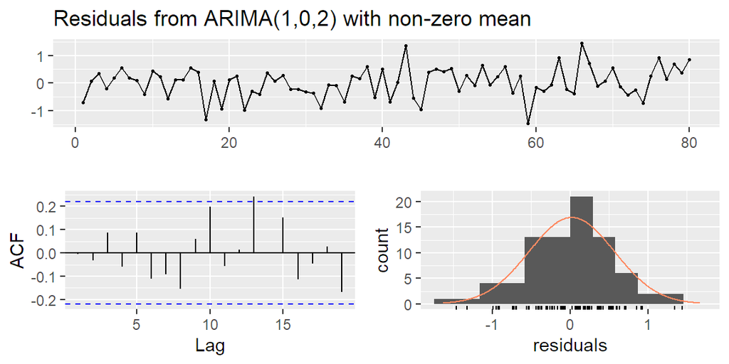

```
##
##  Ljung-Box test
##
## data:  Residuals from ARIMA(1,0,2) with non-zero mean
## Q* = 9.7478, df = 6, p-value = 0.1357
##
## Model df: 4.   Total lags used: 10
```

```r
checkresiduals(arimaModel_102)
```

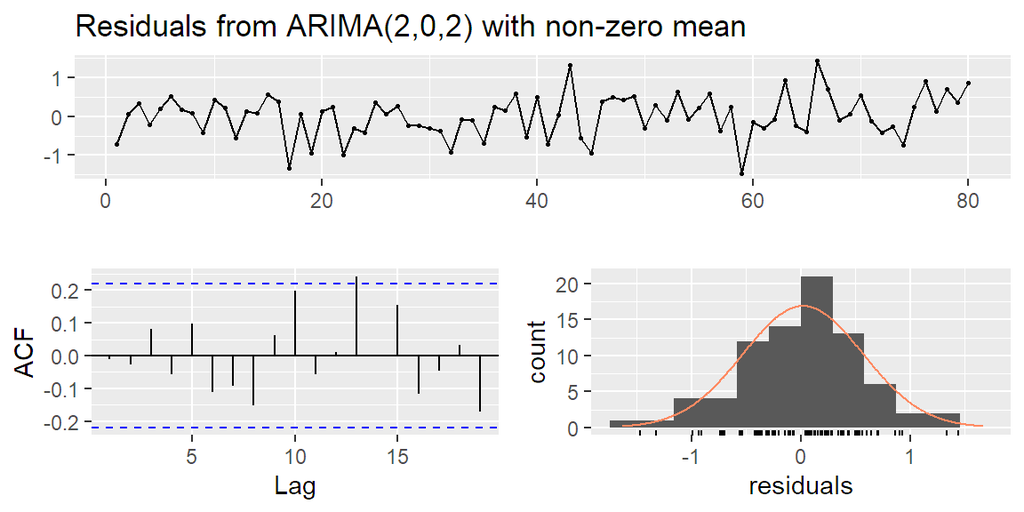

```
##
##  Ljung-Box test
##
## data:  Residuals from ARIMA(2,0,2) with non-zero mean
## Q* = 9.7188, df = 5, p-value = 0.08361
##
## Model df: 5.   Total lags used: 10
```

```r
checkresiduals(arimaModel_202)
```

MA차수를 높인 결과 두 모델 모두 잔차의 독립성을 만족하고 정상성과 정규성 또한 모두 만족하는 것으로 보입니다. 이에 따라 두 모델을 가지고 예측을 진행하도록 하겠습니다.

##### (4) 예측 및 정확성

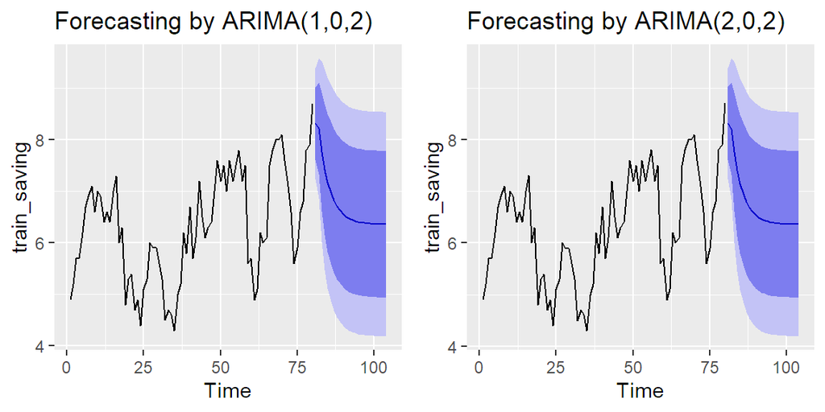

```r
forecast1 = forecast::forecast(arimaModel_102, h=24)
forecast2 = forecast::forecast(arimaModel_202, h=24)

p1= autoplot(forecast1) + ggtitle("Forecasting by ARIMA(1,0,2)")
p2= autoplot(forecast2) + ggtitle("Forecasting by ARIMA(2,0,2)")
grid.arrange(p1,p2,ncol=2)
```

```r
accuracy(arimaModel_102)
```

```
##                      ME      RMSE       MAE        MPE     MAPE      MASE
## Training set 0.01932757 0.5474494 0.4332655 -0.4749327 7.043337 0.9055019
##                      ACF1
## Training set -0.006043453
```

```r
accuracy(arimaModel_202)
```

```
##                      ME      RMSE       MAE        MPE     MAPE      MASE
## Training set 0.01893835 0.5474252 0.4334542 -0.4845584 7.049504 0.9058964
##                     ACF1
## Training set -0.01170381
```

##### (5) test data 예측값, 실제값 비교

```r
df.forecast2 = data.frame(forecast2)
regr.eval(test_saving, df.forecast2$Point.Forecast)
```

```
##       mae       mse      rmse      mape
## 1.2107388 1.9631215 1.4011144 0.2338919
```

RMSE가 1.4011으로 0에 가깝지는 않아 예측 성능이 좋은 것은 아니지만 어느 정도의 예측성능은 이루어진 것 같습니다.